# Project Python Foundations: FoodHub Data Analysis

**Marks: 60**

### Context

The number of restaurants in New York is increasing day by day. Lots of students and busy professionals rely on those restaurants due to their hectic lifestyles. Online food delivery service is a great option for them. It provides them with good food from their favorite restaurants. A food aggregator company FoodHub offers access to multiple restaurants through a single smartphone app.

The app allows the restaurants to receive a direct online order from a customer. The app assigns a delivery person from the company to pick up the order after it is confirmed by the restaurant. The delivery person then uses the map to reach the restaurant and waits for the food package. Once the food package is handed over to the delivery person, he/she confirms the pick-up in the app and travels to the customer's location to deliver the food. The delivery person confirms the drop-off in the app after delivering the food package to the customer. The customer can rate the order in the app. The food aggregator earns money by collecting a fixed margin of the delivery order from the restaurants.

### Objective

The food aggregator company has stored the data of the different orders made by the registered customers in their online portal. They want to analyze the data to get a fair idea about the demand of different restaurants which will help them in enhancing their customer experience. Suppose you are hired as a Data Scientist in this company and the Data Science team has shared some of the key questions that need to be answered. Perform the data analysis to find answers to these questions that will help the company to improve the business.

### Data Description

The data contains the different data related to a food order. The detailed data dictionary is given below.

### Data Dictionary

- order_id: Unique ID of the order
- customer_id: ID of the customer who ordered the food
- restaurant_name: Name of the restaurant
- cuisine_type: Cuisine ordered by the customer
- cost: Cost of the order
- day_of_the_week: Indicates whether the order is placed on a weekday or weekend (The weekday is from Monday to Friday and the weekend is Saturday and Sunday)
- rating: Rating given by the customer out of 5
- food_preparation_time: Time (in minutes) taken by the restaurant to prepare the food. This is calculated by taking the difference between the timestamps of the restaurant's order confirmation and the delivery person's pick-up confirmation.
- delivery_time: Time (in minutes) taken by the delivery person to deliver the food package. This is calculated by taking the difference between the timestamps of the delivery person's pick-up confirmation and drop-off information

### Let us start by importing the required libraries

```python
# importing libraries for data manipulation
import numpy as np   #importing numpy as np
import pandas as pd  #importing pandas as pd

# import libraries for data visualization
import matplotlib.pyplot as plt #importing matplotlib as plt
import seaborn as sns           #imposting seaborn as sns
```

### Understanding the structure of the data

```python
# importing and mounting drive for colab to access dataset as dataset if stored in drive
from google.colab import drive
drive.mount('/content/drive')
```

```python
# reading foodhub dataset from drive as dataframe named df
df = pd.read_csv('/content/drive/MyDrive/Python Course/foodhub_order.csv')
# save a copy of original data
df_foodhub_orig = df.copy()
# head method returns the first 5 rows
df.head()
```

|  | order_id | customer_id | restaurant_name | cuisine_type | cost_of_the_order | day_of_the_week | rating | food_preparation_time | delivery_time |
| --- | --- | --- | --- | --- | --- | --- | --- | --- | --- |
| 0 | 1477147 | 337525 | Hangawi | Korean | 30.75 | Weekend | Not given | 25 | 20 |
| 1 | 1477685 | 358141 | Blue Ribbon Sushi Izakaya | Japanese | 12.08 | Weekend | Not given | 25 | 23 |
| 2 | 1477070 | 66393 | Cafe Habana | Mexican | 12.23 | Weekday | 5 | 23 | 28 |
| 3 | 1477334 | 106968 | Blue Ribbon Fried Chicken | American | 29.20 | Weekend | 3 | 25 | 15 |
| 4 | 1478249 | 76942 | Dirty Bird to Go | American | 11.59 | Weekday | 4 | 25 | 24 |

#### Observations:

- *The DataFrame has 9 columns as mentioned in the Data Dictionary. Data in each row corresponds to the order placed by a customer.*

```python
#using shape method to get the rows and column count of dataset
num_rows_columns=df.shape #creating tuple varliable to save return of shape method.
#print rows and columns. index 0 in tuple = rows and index 1 = columns , coverting them to string to use in print.
print('There are ',str(num_rows_columns[0]), ' rows and ' , str(num_rows_columns[1]),'columns in FoodHub dataset.')
```

```
There are  1898  rows and  9 columns in FoodHub dataset.
```

#### Observations:

- *There are 1898 rows and 9 columns in FoodHub dataset.*

```python
# Using info() to print a concise summary of the DataFrame
df.info()
```

```
<class 'pandas.core.frame.DataFrame'>
RangeIndex: 1898 entries, 0 to 1897
Data columns (total 9 columns):
 #   Column                 Non-Null Count  Dtype
---  ------                 --------------  -----
 0   order_id               1898 non-null   int64
 1   customer_id            1898 non-null   int64
 2   restaurant_name        1898 non-null   object
 3   cuisine_type           1898 non-null   object
 4   cost_of_the_order      1898 non-null   float64
 5   day_of_the_week        1898 non-null   object
 6   rating                 1898 non-null   object
 7   food_preparation_time  1898 non-null   int64
 8   delivery_time          1898 non-null   int64
dtypes: float64(1), int64(4), object(4)
memory usage: 133.6+ KB
```

#### Observations:

- int types(order_id,customer_id,food_preparation_time,delivery_time)
- float types(cost_of_the_order)
- object types(restaurant_name,cuisine_type,day_of_the_week,rating)
- memory usage: 133.6+ KB

```python
# coverting "objects" to "category" reduces the data space required to store the dataframe
# converting 'restaurant_name', 'cuisine_type', 'day_of_the_week' into categorical data
df['restaurant_name'] = df.restaurant_name.astype('category')
df['cuisine_type'] = df.cuisine_type.astype('category')
df['day_of_the_week']= df.day_of_the_week.astype('category')
# concise summary of the DataFrame
df.info()
```

```
<class 'pandas.core.frame.DataFrame'>
RangeIndex: 1898 entries, 0 to 1897
Data columns (total 9 columns):
 #   Column                 Non-Null Count  Dtype
---  ------                 --------------  -----
 0   order_id               1898 non-null   int64
 1   customer_id            1898 non-null   int64
 2   restaurant_name        1898 non-null   category
 3   cuisine_type           1898 non-null   category
 4   cost_of_the_order      1898 non-null   float64
 5   day_of_the_week        1898 non-null   category
 6   rating                 1898 non-null   object
 7   food_preparation_time  1898 non-null   int64
 8   delivery_time          1898 non-null   int64
dtypes: category(3), float64(1), int64(4), object(1)
memory usage: 102.7+ KB
```

### Observation

- Reduced memory usage: 102.7+ KB after converting 3 columns to category

```python
# checking missing values using isnull method
df.isnull().sum()
```

```
order_id                 0
customer_id              0
restaurant_name          0
cuisine_type             0
cost_of_the_order        0
day_of_the_week          0
rating                   0
food_preparation_time    0
delivery_time            0
dtype: int64
```

#### Observations:

- Data has 0 null values

```python
# Statistical summary of data using describe method and transposing it to see every column summary as row data.
# set precision
pd.set_option('display.float_format', lambda x: '%.2f' % x)
# show summary stats
df.describe().T #include='all'is used to get categorical column summaries as well.
```

|  | count | mean | std | min | 25% | 50% | 75% | max |
| --- | --- | --- | --- | --- | --- | --- | --- | --- |
| order_id | 1898.00 | 1477495.50 | 548.05 | 1476547.00 | 1477021.25 | 1477495.50 | 1477969.75 | 1478444.00 |
| customer_id | 1898.00 | 171168.48 | 113698.14 | 1311.00 | 77787.75 | 128600.00 | 270525.00 | 405334.00 |
| cost_of_the_order | 1898.00 | 16.50 | 7.48 | 4.47 | 12.08 | 14.14 | 22.30 | 35.41 |
| food_preparation_time | 1898.00 | 27.37 | 4.63 | 20.00 | 23.00 | 27.00 | 31.00 | 35.00 |
| delivery_time | 1898.00 | 24.16 | 4.97 | 15.00 | 20.00 | 25.00 | 28.00 | 33.00 |

#### Observations:

The above table displays the descriptive analysis for all numeric columns.

1. Cost of order - mean is 16.50, with a 7.48 standard deviation and range of 4.47 - 35.41
2. Food Preparation Time - mean is 27 minutes, with a 5 minute standard deviation and range of 20 - 35 minutes
3. Delivery Time - average is 24 minutes, with a 5 minute standard deviation and range is 15 - 33 minutes
4. Standard deviation for all variables is low, so data is not very spread out
5. Order and Customer are categorical in nature so unimportant in this context

```python
# Checking number of orders that were not rated.
len(df[df['rating']=='Not given']) #using the filter 'Not Given' on rating column and calculting lenght.
```

```
736
```

### Observation

- 736 rows out of 1898 are not rated.

### Explaratory data analysis.

### Order ID

```python
#Exploring ORDER ID Cheking Unique count
unique_order = df['order_id'].nunique()
unique_order
```

```
1898
```

### Customer ID

```python
#Exploring Customer Checking unique count
unique_customer = df['customer_id'].nunique()
unique_customer
```

```
1200
```

```python
#Repeat Customer
repeat_customer = unique_order - unique_customer
repeat_customer
```

```
698
```

```python
#Repeat customer pct
repeat_customer_pct=repeat_customer/unique_order*100
round(repeat_customer_pct,2)
```

```
36.78
```

### Restaurant Name

```python
#Checking unique resturants count
df['restaurant_name'].nunique()
```

```
178
```

### Observation

- There are 178 unique restaruants in data.

### Cuisine Type

```python
#Checking no of unique cuisines
unique_cuisine = df['cuisine_type'].nunique()
print (unique_cuisine)
```

```
14
```

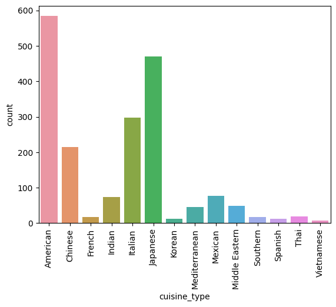

```python
# Using countplot for cuisine as there are only 14 distinct cuisines
cuisine = sns.countplot(data=df,x='cuisine_type')
cuisine.set_xticklabels(cuisine.get_xticklabels(), rotation=90);
```

#### Observation

- There are 14 unique dishes ordered.
- American is most popular cuisine followed by Japanese and then Italian.

### Delivery time

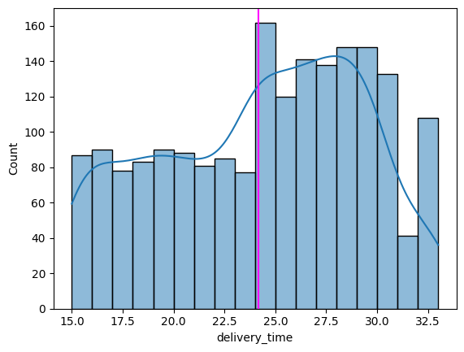

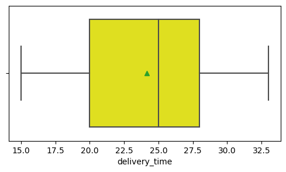

```python
#Histogram plot of delivery time with kde true restricting binwidth to 1
sns.histplot(data=df,x='delivery_time',kde= True,binwidth=1)
plt.axvline(x=df.delivery_time.mean(), color='magenta')
plt.show()
#Boxplot of delivery time on x axis
plt.figure(figsize=(6, 3))
sns.boxplot(data=df,x='delivery_time',showmeans=True,color='yellow')
plt.show()
```

#### Observations

- Delivery time has slightly left skewed.
- There are no outliers.
- Higest number of observations are at 24-25 minutes

### Food prepare time.

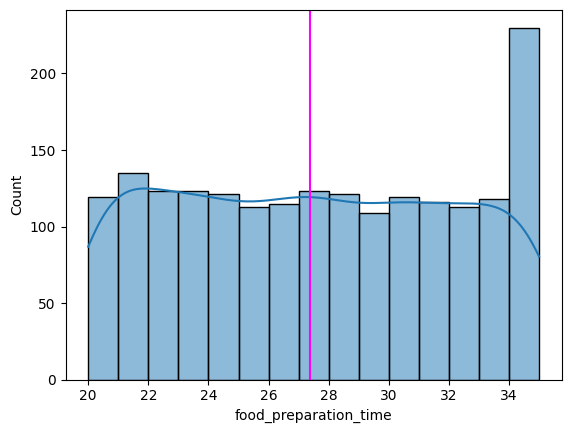

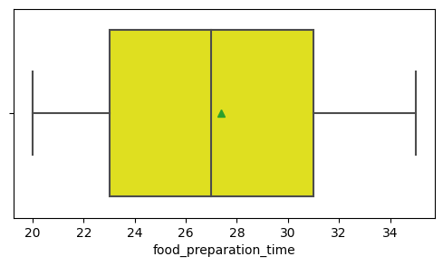

```python
sns.histplot(data=df, x='food_preparation_time',kde=True,binwidth=1)
plt.axvline(x=df.food_preparation_time.mean(), color='magenta')
plt.show()
plt.figure(figsize=(6, 3))
sns.boxplot(data=df, x='food_preparation_time',showmeans=True,color='yellow')
plt.show()
```

### Observations

- Food Prep time has fairly uniform distribution.
- There are no outliers.
- Higest number of observations are at 34-35 minutes

### Cost of the order

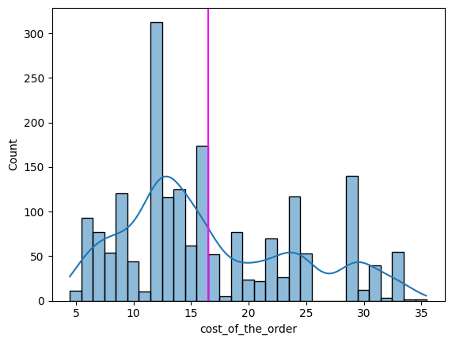

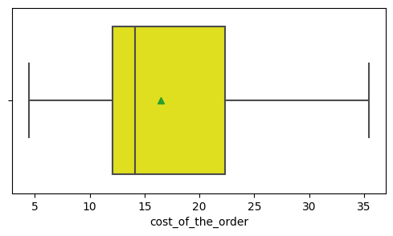

```python
sns.histplot(data=df,x='cost_of_the_order',binwidth=1,kde=True)
plt.axvline(x=df.cost_of_the_order.mean(), color='magenta')
plt.show()
plt.figure(figsize=(6, 3))
sns.boxplot(data=df,x='cost_of_the_order',showmeans=True,color='yellow')
plt.show()
```

### Observation

- Cost of order has positive right skewness
- Highest observations are at 11-12.

#### Rating

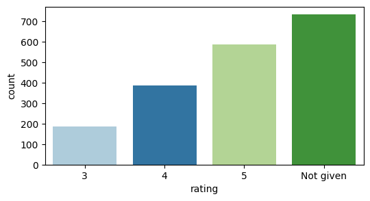

```python
plt.figure(figsize=(6, 3))
df['rating'] = pd.Categorical(df['rating'], ['3', '4', '5', 'Not given']) # There are only 4 ratings , sorting them from lowest rated 3 to higest rated 5 for better reprentation
sns.countplot(data=df,x='rating', palette='Paired')
plt.show()
```

### Obervations

- Maximum orders are not rated . Rating 5 that is the best rating, it has the second higest count.

#### Dayof the week

```python
df['day_of_the_week'].nunique()
```

```
2
```

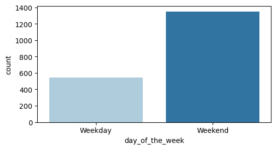

```python
plt.figure(figsize=(6, 3))
sns.countplot(data=df,x='day_of_the_week',palette='Paired')
plt.show()
```

### Observation

- Number of weekend orders far exceed weekday orders.

```python
# Top 5 restaurant_name
df_resturant_orders=  df.groupby('restaurant_name').size() # group the dataset by restaurant and get the size of the list
df_top_5_restaurant = df_resturant_orders.sort_values(ascending=False).head(5) # sort the grouped dataframe by size in descending order and get the top 5 rows
print(df_top_5_restaurant)
```

```
restaurant_name
Shake Shack                  219
The Meatball Shop            132
Blue Ribbon Sushi            119
Blue Ribbon Fried Chicken     96
Parm                          68
dtype: int64
```

#### Observations:

Top 5 restaurant_name by number of orders

- - Shake Shack
- - The Meatball Shop
- - Blue Ribbon Sushi
- - Blue Ribbon Fried Chicken
- - Parm 6

```python
#most popular cuisine on weekends
df_weekend = df[df['day_of_the_week'] == 'Weekend']   # Filter the dataset for weekend
df_weekend_cuisine_sold = df_weekend.groupby('cuisine_type').size() # group the weekend dataset by cusine type and get the size
print(df_weekend_cuisine_sold.sort_values(ascending=False).head(1)) #get the first row of the result by sorting descending
```

```
cuisine_type
American    415
dtype: int64
```

#### Observations:

- American is most popular weekend cuisine with total 415 orders

```python
# calculate the percentage of orders that cost more than 20 dollars
percentage_orders_gt_20 = (df[df['cost_of_the_order'] > 20]['cost_of_the_order'].count() / df['cost_of_the_order'].count()) * 100

print(f"{percentage_orders_gt_20:.2f}% of the orders cost more than $20.")
```

```
29.24% of the orders cost more than $20.
```

#### Observations:

- 29.24% of the orders cost more than $20.

```python
# calculate mean order delivery time
avg_delivery_time = df['delivery_time'].mean()
print(f"{avg_delivery_time:.2f}  minutes is the avg delivery time.")
```

```
24.16  minutes is the avg delivery time.
```

#### Observations:

- 24.16 minutes is the avg delivery time.

### **Question 11:** The company has decided to give 20% discount vouchers to the top 3 most frequent customers. Find the IDs of these customers and the number of orders they placed.

```python
# find 3 most frequent customers

df_customer=  df.groupby('customer_id').size() # group the dataset by customer id  and get the size of the list
df_top_3_customer = df_customer.sort_values(ascending=False).head(3) # get the top 3 rows sorted descenduing
print(df_top_3_customer)
```

```
customer_id
52832    13
47440    10
83287     9
dtype: int64
```

```python
# Alternate way to Find top3 customers using value counts method
print(df['customer_id'].value_counts().head(3))
```

```
52832    13
47440    10
83287     9
Name: customer_id, dtype: int64
```

#### Observations:

Top 3 Customer ID by number of Orders

- 52832
- 47440
- 83287

### Multivariate Analysis

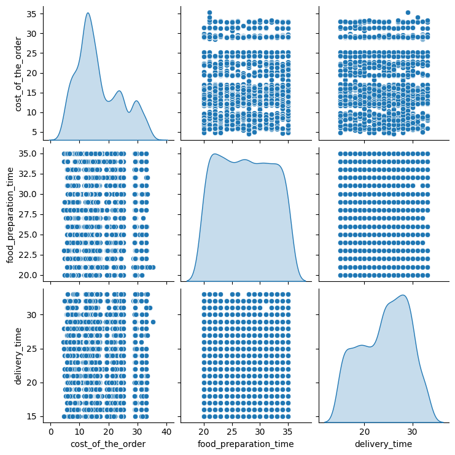

```python
# Analyze pairplot of variables
sns.pairplot(df, vars=['cost_of_the_order', 'food_preparation_time', 'delivery_time'], diag_kind="kde");
```

### Observation

- Pairplot does not indicate significant correlation.

df.corr()

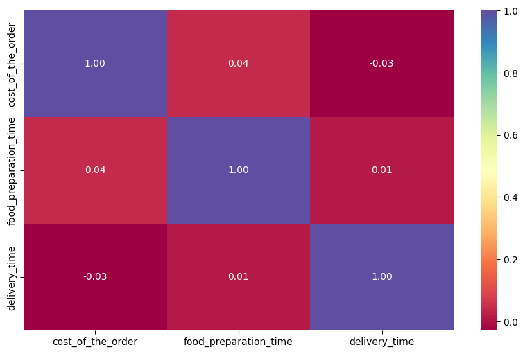

```python
## Heatmap should confirm above analysis
column_list = ['cost_of_the_order', 'food_preparation_time', 'delivery_time']
plt.figure(figsize=(10, 6))
sns.heatmap(df[column_list].corr(), annot=True, fmt=".2f", cmap="Spectral")
plt.show()
```

### Observation

- No signification corr

### Cuisine vs Cost of order

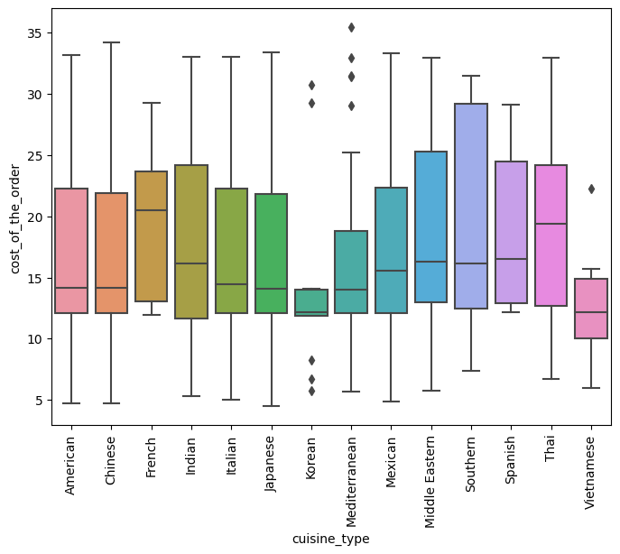

```python
#Relationship between cost of the order and cuisine type using boxplot
plt.figure(figsize=(8,6))
sns.boxplot(x = "cuisine_type", y = "cost_of_the_order", data = df)
plt.xticks(rotation = 90)
plt.show()
```

### Observation

- *Many cusine types has outlier costs including Korean , Mediterranean and Vitenamese . Korean cuisine has outliers at both end of cost . Other two has higher cost outliers.*

### Determine Revenue generated by cuisine

```python
df.groupby(['cuisine_type'])['cost_of_the_order'].sum().sort_values(ascending = False).head(14) # Total cost by cuisine highest to lowest
```

```
cuisine_type
American         9530.78
Japanese         7663.13
Italian          4892.77
Chinese          3505.62
Mexican          1303.85
Indian           1235.14
Middle Eastern    922.21
Mediterranean     711.84
Thai              364.95
French            356.29
Southern          328.11
Spanish           227.93
Korean            182.02
Vietnamese         90.18
Name: cost_of_the_order, dtype: float64
```

### Observation

- American followed by Japanese then Italian generate highest revenue.
- Vietnamese revenue is lowest.

### Cuisine vs Food Vs Prpe time

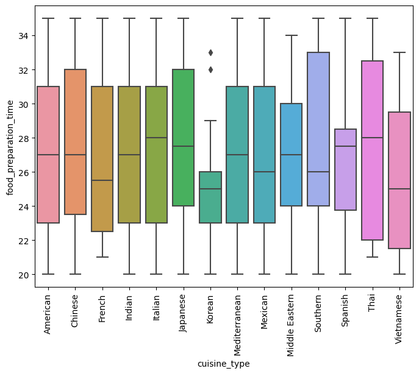

```python
#Relationship between cost of the order and cuisine type using boxplot
plt.figure(figsize=(8,6))
sns.boxplot(x = "cuisine_type", y = "food_preparation_time", data = df)
plt.xticks(rotation = 90)
plt.show()
```

### Observation

- Some Korean dishes has high preperation time outliers
- American, Indian and Mediterranean disches have almost identical plots, their curve is balanced too
- Other dishes has skewed right or left relationships with preperation time.

### Determine top revenue earning restuarants

```python
df.groupby(['restaurant_name','cuisine_type'])['cost_of_the_order'].sum().sort_values(ascending = False).head(14)
```

```
restaurant_name                cuisine_type
Shake Shack                    American       3579.53
Blue Ribbon Sushi              Japanese       1903.95
The Meatball Shop              Italian        1821.01
Blue Ribbon Fried Chicken      American       1662.29
Parm                           Italian        1112.76
RedFarm Broadway               Chinese         965.13
RedFarm Hudson                 Chinese         921.21
TAO                            Japanese        834.50
Han Dynasty                    Chinese         755.29
Blue Ribbon Sushi Bar & Grill  Japanese        666.62
Rubirosa                       Italian         660.45
Sushi of Gari 46               Japanese        640.87
Nobu Next Door                 Japanese        623.67
Five Guys Burgers and Fries    American        506.47
Name: cost_of_the_order, dtype: float64
```

### Observation

- ShakeShack, Blue Ribbon Sushi,TheMeatball Shop are top 3 revenue earning res.

### Rating Vs Delivery Time

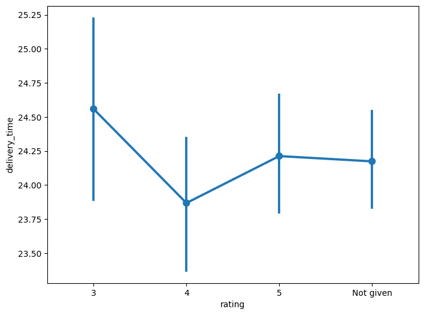

```python
# Relationship between rating and delivery time
plt.figure(figsize=(8, 6))
sns.pointplot(x = 'rating', y = 'delivery_time', data = df)
plt.show()
```

### Rating Vs Delivery Time Vs Dayof week

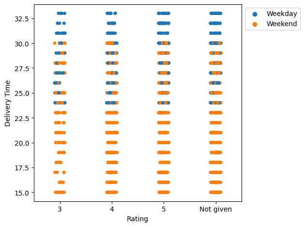

```python
# Analyze if rating has any relationship to delivery time and day of week.
sns.stripplot(data=df, x="rating", y="delivery_time", hue="day_of_the_week")
plt.xticks(size=10)
plt.ylabel('Delivery Time', size=10)
plt.xlabel('Rating', size=10)
plt.legend(bbox_to_anchor=(1, 1))
plt.tight_layout()
```

### Rating vs Food Prep Time

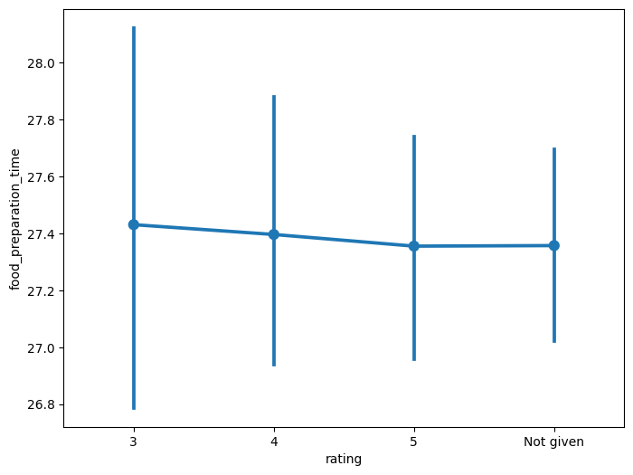

```python
#Relationship between rating and food prep time
plt.figure(figsize=(8, 6))
sns.pointplot(x = 'rating', y = 'food_preparation_time', data = df)
plt.show()
```

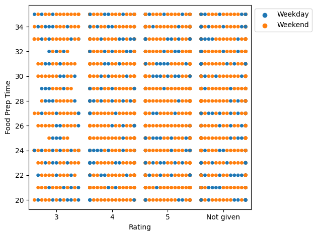

```python
# Analyze if rating has any relationship to food prep and day of week.
import warnings
warnings.filterwarnings('ignore', category=UserWarning)  #filtering user warnings while plotting swarmplot
sns.swarmplot(x=df['rating'], y=df['food_preparation_time'], hue=df['day_of_the_week'])
plt.xticks(size=10)
plt.ylabel('Food Prep Time', size=10)
plt.xlabel('Rating', size=10)
plt.legend(bbox_to_anchor=(1, 1))
plt.tight_layout()
```

### Rating vs Cost of order

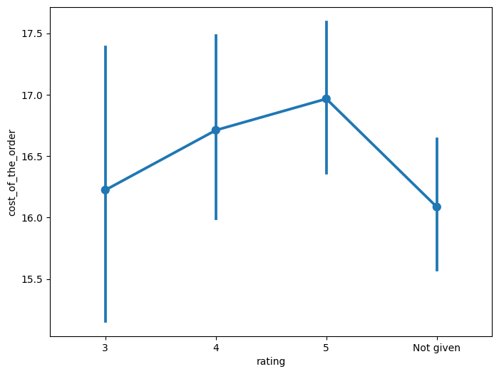

```python
#Relationship between rating and cost of order time
plt.figure(figsize=(8, 6))
sns.pointplot(x = 'rating', y = 'cost_of_the_order', data = df)
plt.show()
```

### Observation

```python
# Find the restaurants fulfilling the criteria to get the promotional offer - the restaurants must have a rating count of more than 50 and the average rating should be greater than 4
# creating a rating count dataframe for counts per resturant the rated rows by excluding not given rating rows grouping on restuarant name
df_rating_count=df[df['rating'] != 'Not given'].groupby(['restaurant_name'])['rating'].count().reset_index().copy()
#creating df of all restuarants with rating count > 50
df_rating_above_50 = df_rating_count[df_rating_count['rating'] > 50].copy()
# creating dataframe of all rated resutrants with mean (avg) rating group it on resutrant name
df_rating_avg=df_rating_count.groupby(['restaurant_name'])['rating'].mean().reset_index().copy()
# creating dataframe of all the resturants having avg rating greater than 4
df_rating_avg_above_4 = df_rating_avg[df_rating_avg['rating']> 4].copy()
#  Join  df_rating_above_50,df_rating_avg_above_4,how="inner",on='restaurant_name' to get the resturant that qualify both criteria
df_rest_50_avg4_rating = pd.merge(df_rating_above_50,df_rating_avg_above_4,how="inner",on='restaurant_name')
# Get the info of new dataframe for restuarant column
df_rest_50_avg4_rating['restaurant_name'].info()
```

```
<class 'pandas.core.series.Series'>
Int64Index: 4 entries, 0 to 3
Series name: restaurant_name
Non-Null Count  Dtype
--------------  -----
4 non-null      category
dtypes: category(1)
memory usage: 5.5 KB
```

```python
#since new DF has total 4 entries and all not null , we can use simple head method to get all the names
df_rest_50_avg4_rating['restaurant_name'].head()
```

```
0    Blue Ribbon Fried Chicken
1            Blue Ribbon Sushi
2                  Shake Shack
3            The Meatball Shop
Name: restaurant_name, dtype: category
Categories (178, object): [''wichcraft', '12 Chairs', '5 Napkin Burger', '67 Burger', ..., 'brgr',
                           'da Umberto', 'ilili Restaurant', 'indikitch']
```

#### Observations:

- Blue Ribbon Fried Chicken
- Blue Ribbon Sushi
- Shake Shack
- The Meatball Shop

```python
# The company charges the restaurant 25% on the orders having cost greater than 20 dollars and 15% on the orders having cost greater than 5 dollars.
# Find the net revenue generated by the company across all orders.
# add new column that stores company charges
df['app_charge'] = [cost * 0.25 if cost > 20 else cost * 0.15 if cost >5 else 0
                            for cost in df['cost_of_the_order']]

# separate the two types  of charges in different df
df_over20 = df[df['cost_of_the_order']>20]
rev_over20 = df_over20['app_charge'].sum()
print('Total revenue generated by orders over $20 - ',str(round(rev_over20, 2)))

df_over5 = df[df['cost_of_the_order']>5]
df_over5 = df_over5[df_over5['cost_of_the_order']<20]
rev_over5 = df_over5['app_charge'].sum()
print('Total revenue generated by orders over $5 - ' ,str(round(rev_over5, 2)))

# take the sum of the new column
total_revenue = df['app_charge'].sum()
print('Total revenue generated by orders ' ,str(round(total_revenue, 2)))
```

```
Total revenue generated by orders over $20 -  3688.73
Total revenue generated by orders over $5 -  2477.58
Total revenue generated by orders  6166.3
```

#### Observations:

- The company total revenue is around 6166.3 dollars.

```python
# The company wants to analyze the total time required to deliver the food. What percentage of orders take more than 60 minutes to get delivered from the time the order is placed?
# (The food has to be prepared and then delivered.)
# add another column  to dataframe for total time that is sum of food preperation time and delivery time
df['total_time']= df['food_preparation_time'] + df['delivery_time']
order_time_gt_60 = df[df['total_time'] > 60]                      # finding all orders that have total time gt 60
pct_orders = 100 * (order_time_gt_60.shape[0]/df.shape[0])        # getting the percentage by dividing number of rows in order_time_gt_60 with total number of rows
print ('There are ', round(pct_orders,2), '% orders having total time greater than 60')
```

```
There are  10.54 % orders having total time greater than 60
```

#### Observations:

- There are 10.54% orders having total time greater than 60.

```python
#How does the mean delivery time vary during weekdays and weekends

mean_time_weekday  = round(df[df['day_of_the_week']=='Weekday']['delivery_time'].mean(),2)  #filter day of the week for value 'Weekday' and get mean , round the result to 2 decimal
mean_time_weekends = round(df[df['day_of_the_week']=='Weekend']['delivery_time'].mean(),2)  #filter day of the week for value 'Weekend' and get mean , round the result to 2 decimal
print ('Average delivery time for weekday is (minutes):', mean_time_weekday)
print ('Average delivery time for weekends is (minutes):', mean_time_weekends)
```

```
Average delivery time for weekday is (minutes): 28.34
Average delivery time for weekends is (minutes): 22.47
```

### Observation:

- Average delivery time for weekday is (minutes): 28.34
- Average delivery time for weekends is (minutes): 22.47
- Weekday delivery time is almost 6 min slower than weekend.

### Conclusion and Recommendations

### Conclusions:

- The highest number of responses to rating is 'not given'.
- The top 5 restaurants by number of orders represent American, Italian and Japanese cuisines.
- Across all cuisine types of weekend days are when the most orders get placed.
- Prep time, delivery time, and cost of order do not seem to be influencing the rating given by any significant measure.
- It seems that three metrics are in a reasonable range in relation to customer satisfaction.
- Weekday average delivery time is higher by almost 6 minutes and 10.5% of all orders have a total delivery time of over 60 minutes.
- Revenue generated by charging 25% & 15% on orders between $5 and $20 would be over $6,000 of revenue. Indicating increased revenue.

### Recommendations:

- Consider improvements in processes or changes to the app interface to encourage people to give a rating should improve this metric.
- Consider marketing efforts that would target restaurants of top cuisine types e.g. American, Japanese, and Italian.
- Consider marketing effort to boost Weekday orders.
- Investigate what changes occur on the weekend days vs. weekdays regarding delivery processes to speed up weekday delivery time.
- Consider revenue generation options like charging commission based on cost of order.